# Homework 2

Dorukhan Kılınç - IE360 - Fall 2020

December 17, 2020

# 1.Introduction

Inflation is a general, continuous increase in the prices calculated by comparing two consumer price indexes from different years. In Turkey’s economy, rapidly increasing inflation has been a major problem damaging both consumers and producers for a long time. It damages consumers in the sense that as inflation increases, so does the price of the goods and producers in the sense that interest rates go upwards to compensate the inflation rate. Inflation rate affects unemployment rate as well.

The aim of this homework is to examine inflation rate by looking at Turkey’s consumer price index and try to find the answer of **“Are inflation rate, interest rate and unemployment rate related?”**.

# 2.Data Manipulation and Visualization

### a.Data Manipulation

The datasets with which I will try to find correlation relationships are taken from [EVDS](https://evds2.tcmb.gov.tr/). In this dataset, CPI’s are calculated based on taking CPI of 2003 equal to 100.

```r
#Datasets are manipulated so that their dates coincide

CPI = read_excel("cpi.xlsx", range = "A52:B150", col_names = c("Date", "Index"))


Interest_Rate = read_excel("faiz_oranları.xlsx", range = "A52:B150", col_names = c("Date", "Interest Rate"))

Unemployment_Rate = read_excel("işsizlik.xlsx", range = "A54:B152", col_names = c("Date", "Unemployment Rate"))

#Datasets are merged in one data table

dt = data.table(Date = CPI$Date, ConsumerPriceIndex = CPI$Index, InterestRate = Interest_Rate$`Interest Rate`, UnemploymentRate = Unemployment_Rate$`Unemployment Rate`)

#Manipulate date column to make it time object by adding a day

dt$Date<-parse_date_time(dt[,Date], "Ym")
dt[,Date := as.Date(Date, format='%Y-%m-%d')]

head(dt)
```

```
##          Date ConsumerPriceIndex InterestRate UnemploymentRate
## 1: 2012-07-01             204.29      31.8500              7.6
## 2: 2012-08-01             205.43      32.7260              8.0
## 3: 2012-09-01             207.55      28.7650              8.3
## 4: 2012-10-01             211.62      29.4425              8.3
## 5: 2012-11-01             212.42      28.6140              8.6
## 6: 2012-12-01             213.23      25.9725              9.3
```

### b.Data Visualization

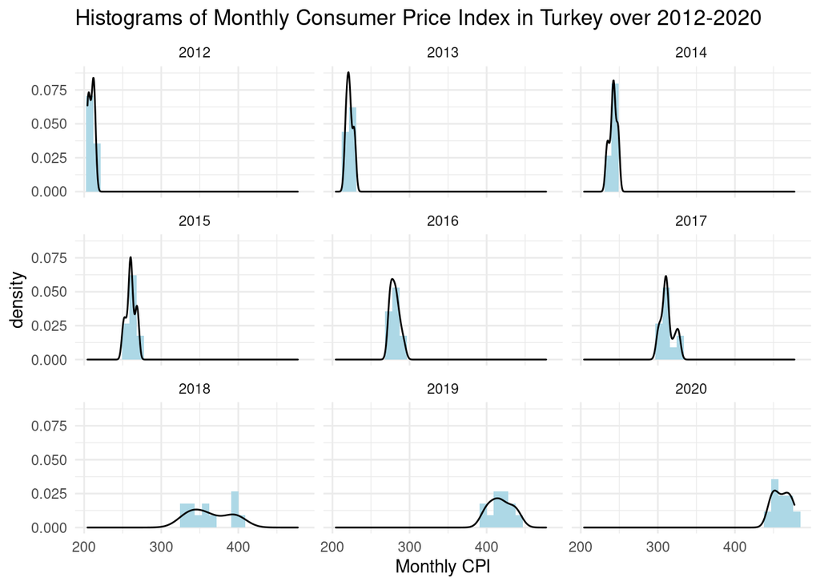

By looking at the histograms, we can say that CPI increases over years. This is because of inflation. As inflation exists, price of the goods increase over years.

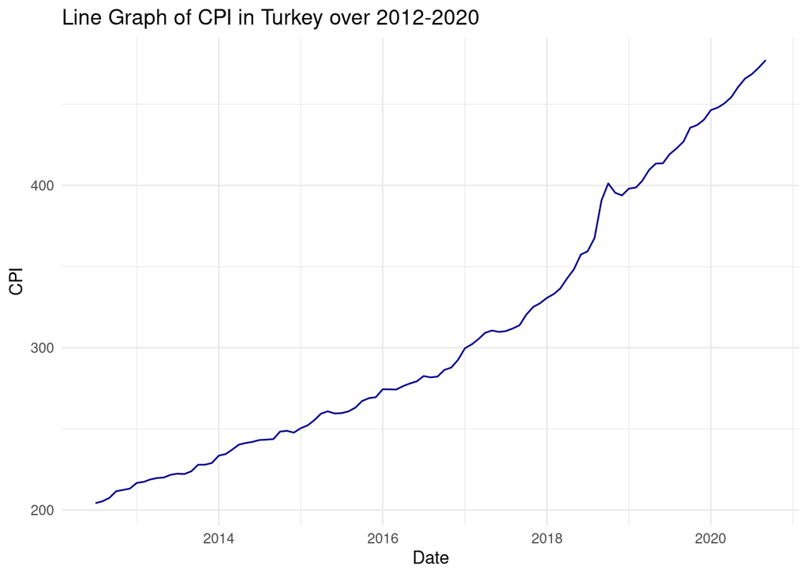

Line plot shows us the upwards trend of CPI clearly. By looking at the plot, we can say that increase in CPI in the last half of the graph is greater. This can be explained with the constant devaluation of TL in the last couple of years.

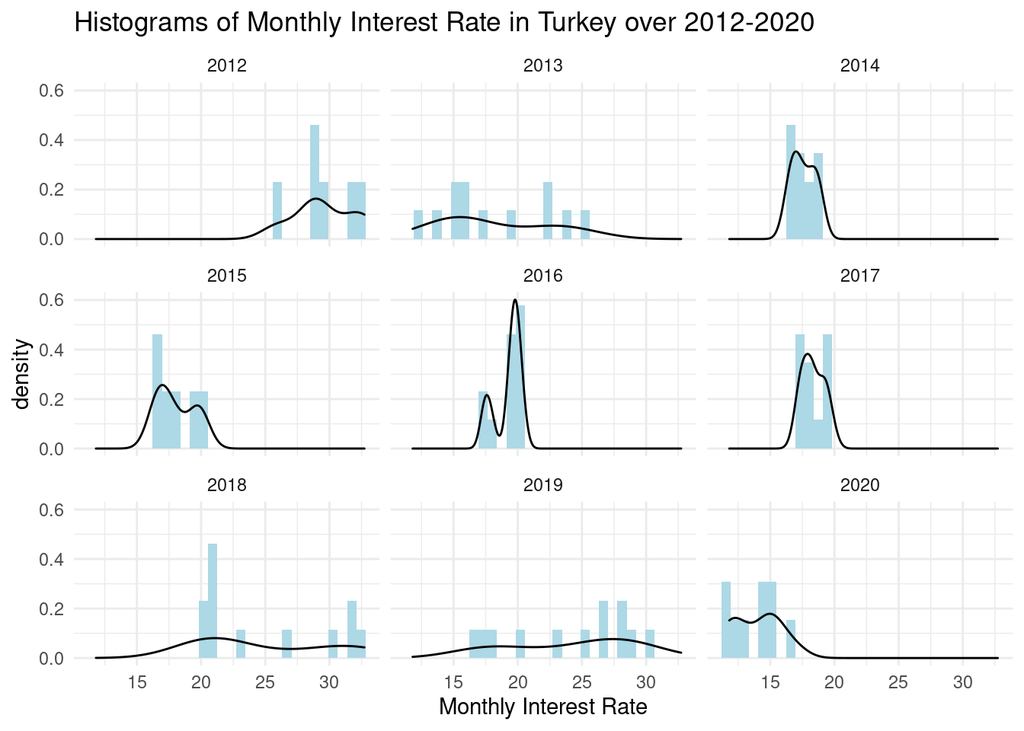

Interest rate histograms shows us no apparent trend or yearly distribution. If there were a trend like CPI has, it would have been said that there was an observable relation between CPI and Interest rates. For further comments about that, we need correlation analysis.

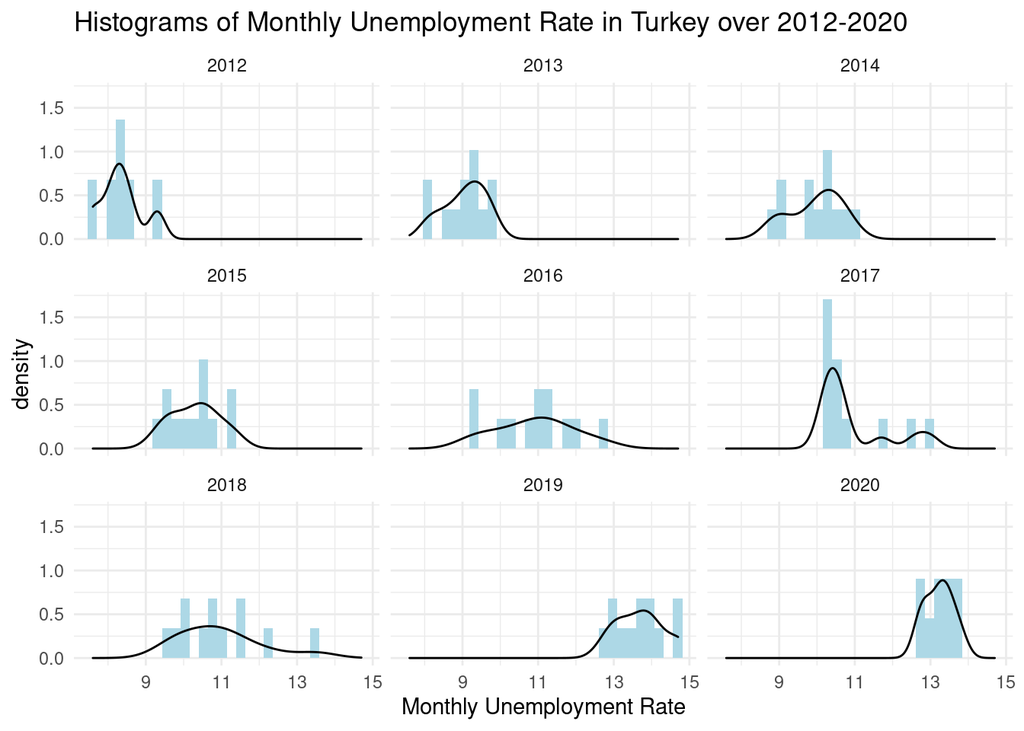

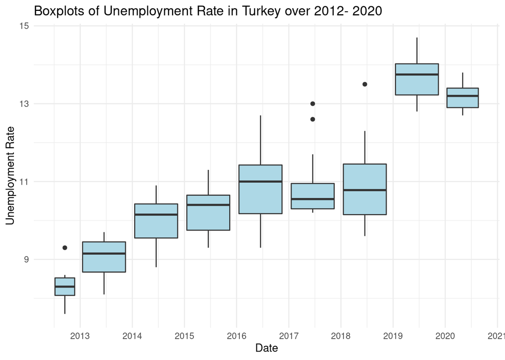

Above boxplot of unemployment rates shows the upwards trends of unemployment more visible than the histograms do. Since monthly data for each year are combined for each box, boxes are located at the middle of the each year. Therefore, for example, the boxplot between 2014 and 2015 contains the data from 2014.

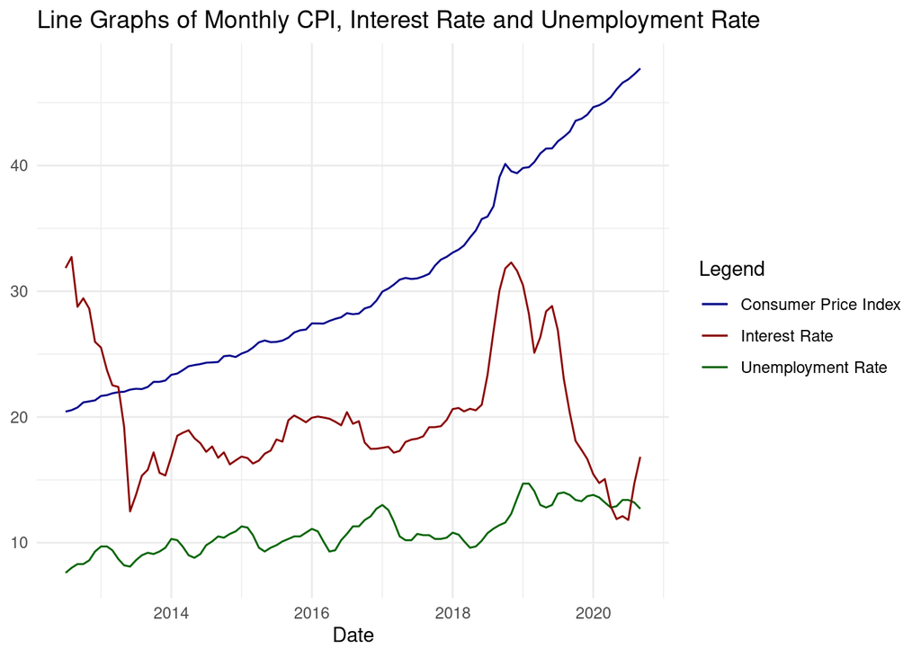

Before moving to correlation analysis, figure above shows all three datasets together. Since CPI is always greater than 200, to be able to show all three together, It is divided by 10 in this graph. While there is no noticeable trend followed by interest rate, it is visible that both CPI and unemployment rate follows an upwards trend.

# 3.Correlation Analysis

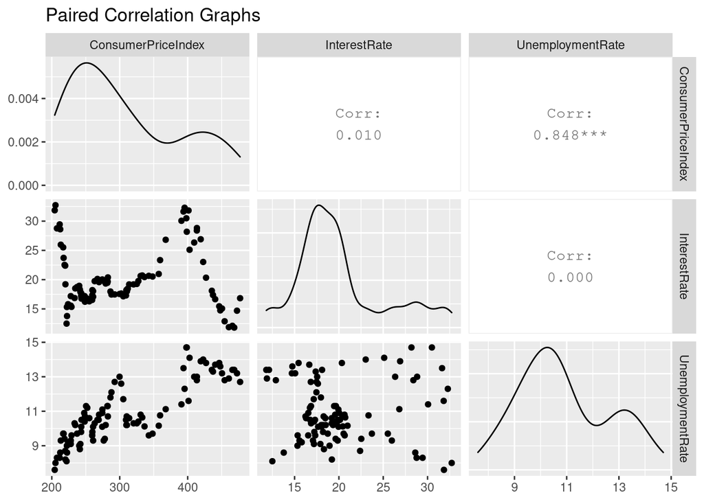

The figure Above shows the correlations between data points. While there is no significant correlation between CPI and interest rate, there clearly is a strong correlation between CPI and unemployment rate. For further information there is the correlation matrix below.

```
##                    ConsumerPriceIndex InterestRate UnemploymentRate
## ConsumerPriceIndex         1.00000000 0.0098985896     0.8483903211
## InterestRate               0.00989859 1.0000000000     0.0003206449
## UnemploymentRate           0.84839032 0.0003206449     1.0000000000
```

Correlation matrix gives us the correlation values clearly. Notice that the matrix is a symmetric matrix with diagonals equal to 1 because its rows and columns contain the same datasets and the correlation of a dataset to itself is equal to 1 by the definition of correlation. From the correlation graphs and the correlation matrix, it is safe to say that interest rate has no statistically significant correlation with neither CPI nor interest rate. On the other hand, CPI and unemployment rate seems to be correlated, which will be explained in more detail.

### Correlation between Consumer Price Index and Unemployment

Since it is found that CPI and unemployment rate are strongly correlated, a further detailed correlation test is also put in the report.

```
##
##  Pearson's product-moment correlation
##
## data:  dt$UnemploymentRate and dt$ConsumerPriceIndex
## t = 15.784, df = 97, p-value < 2.2e-16
## alternative hypothesis: true correlation is not equal to 0
## 95 percent confidence interval:
##  0.7819395 0.8957756
## sample estimates:
##       cor
## 0.8483903
```

Apart from the correlation value found in the above analysis, this correlation test includes a p value, which is important because it is used while testing hypothesis in confidence intervals. Notice p value has a very small value, meaning that the null hypothesis that CPI and unemployment are not correlated can be rejected. So, we can say that CPI and unemployment rate have a relationship. The reason behind this relationship may be that inflation could cause an increase in the unemployment and because inflation is calculated by the change in the CPI, rapid increases in the CPI may cause unemployment rates to go up.

# 4.Conclusion

#### References

[EVDS](https://evds2.tcmb.gov.tr/)